# EXERCÍCIO APLICADO 1:

*Discentes*

```
* Gabriel D'assumpção de Carvalho
```

*Data:* 07/06/2024

# Introdução

Este relatório visa selecionar as melhores alocações de ativos para o ano de 2016 nos Estados Unidos da América (EUA), com base na análise de indicadores macroeconômicos e avaliações quantitativas de empresas e setores pelos analistas. Ao longo deste documento, apresentaremos nossas perspectivas em relação ao mercado financeiro e identificaremos as alocações que parecem mais coerentes com essas perspectivas.

Exploraremos os fatores econômicos e financeiros que moldaram o cenário de investimentos em 2016, analisando tendências emergentes e oportunidades potenciais. Nosso objetivo é fornecer recomendações informadas e estratégias de alocação que possam ajudar os investidores.

A estrutura deste relatório inclui uma revisão detalhada dos indicadores econômicos relevantes, uma análise dos setores-chave e uma conclusão que sintetiza as principais conclusões e recomendações de investimento para o ano de 2016.

## Bibliotecas usadas

```python
#!pip install yfinance
#!pip install pandas
#!pip install mathplotlib
#!pip install numpy
# !pip install fredapi
```

```python
import yfinance as yf #Coleta de dados
import pandas as pd #Manipulação de dados
import matplotlib.pyplot as plt #Gráfico
import numpy as np #Cálculos matemáticos
# from fredapi import Fred #Coleta de dados (EUA)
from datetime import date, datetime #Manipulação de data
```

```python
# Definir os investimentos no portfólio
portfolio_investments = {
    "BAC": 10000, "C": 10000, "FCAU.VI": 2000, "PNR": 8000, "LRCX": 5000,
    'PANW': 5000, 'CHKP': 5000, 'MTN': 5000, 'WMB': 5000, 'SU': 5000,
    'XME': 10000, 'NEM': 5000, 'BTG': 5000, 'CELG': 2000, 'VAR': 2000,
    'UNH': 6000, 'PRNDY': 2000, 'SHEL': 2000, 'GSK': 2000, 'SONY': 4000
}

# Total investido
total_invested = sum(portfolio_investments.values())

# Peso para cada ativo
weights = [w / total_invested for w in portfolio_investments.values()]
```

```python
print(f'Total Invested: {total_invested}')
print(f'Weights: {weights}')
```

[output not shown]

Os ativos selecionados para a composição da carteira ao longo do ano de 2016 foram:

|

| **BANCOS (peso = 20%)** |  |  |
| --- | --- | --- |
| **Ticker** | **Percentual** | **Valor aplicado** |
| BAC | 10.00% | 10,000.00 |
| C | 10.00% | 10,000.00 |

|

| **INDUSTRIA - CONSUMO (10%)** |  |  |
| --- | --- | --- |
| **Ticker** | **Percentual** | **Valor aplicado** |
| FCAU | 2.00% | 2,000.00 |
| PNR | 8.00% | 8,000.00 |

|

| **TECNOLOGIA (20%)** |  |  |
| --- | --- | --- |
| **Ticker** | **Percentual** | **Valor aplicado** |
| LRCX | 5.00% | 5,000.00 |
| PANW | 5.00% | 5,000.00 |
| CHKP | 5.00% | 5,000.00 |
| MTN | 5.00% | 5,000.00 |

|

| **OURO, PETRÓLEO E MINÉRIO DE FERRO (30%)** |  |  |
| --- | --- | --- |
| **Ticker** | **Percentual** | **Valor aplicado** |
| WMB | 5.00% | 5,000.00 |
| SU | 5.00% | 5,000.00 |
| XME | 10.00% | 10,000.00 |
| NEM | 5.00% | 5,000.00 |
| BTG | 5.00% | 5,000.00 |

|

| **HEALTH CARE (10%)** |  |  |
| --- | --- | --- |
| **Ticker** | **Percentual** | **Valor aplicado** |
| CELG | 2.00% | 2,000.00 |
| VAR | 2.00% | 2,000.00 |
| UNH | 6.00% | 6,000.00 |

|

| **BREXIT (10%)** |  |  |
| --- | --- | --- |
| **Ticker** | **Percentual** | **Valor aplicado** |
| PRNDY | 2.00% | 2,000.00 |
| SHEL | 2.00% | 2,000.00 |
| GSK | 2.00% | 2,000.00 |
| SONY | 4.00% | 4,000.00 |

```python
# Definir data de início e fim
start_date = "2016-01-01"
end_date = date.today()
```

```python
# Obter dados do Yahoo Finance
df_portfolio = yf.download(list(portfolio_investments.keys()), start=start_date, end=end_date, progress=False)[['Close','Adj Close']]
df_portfolio = pd.DataFrame(df_portfolio)
df_portfolio.head()
```

```
ERROR:yfinance:
2 Failed downloads:
ERROR:yfinance:['VAR', 'CELG']: YFTzMissingError('$%ticker%: possibly delisted; No timezone found')
```

| Price Ticker Date | Close BAC | Close BTG | Close C | Close CELG | Close CHKP | Close FCAU.VI | Close GSK | Close LRCX | Close MTN | Close NEM | ... | Adj Close PANW | Adj Close PNR | Adj Close PRNDY | Adj Close SHEL | Adj Close SONY | Adj Close SU | Adj Close UNH | Adj Close VAR | Adj Close WMB | Adj Close XME |
| --- | --- | --- | --- | --- | --- | --- | --- | --- | --- | --- | --- | --- | --- | --- | --- | --- | --- | --- | --- | --- | --- |
| 2016-01-04 | 16.43 | 1.03 | 51.130001 | NaN | 79.480003 | NaN | 40.450001 | 77.730003 | 124.150002 | 18.440001 | ... | 57.173332 | 28.447500 | 19.087391 | 29.610744 | 24.730000 | 18.727610 | 102.413422 | NaN | 15.804134 | 13.270395 |
| 2016-01-05 | 16.43 | 1.02 | 50.860001 | NaN | 79.080002 | NaN | 40.680000 | 78.150002 | 125.930000 | 18.420000 | ... | 56.853333 | 28.205044 | 18.829802 | 29.468594 | 25.469999 | 18.742413 | 102.606873 | NaN | 15.858339 | 13.305831 |
| 2016-01-06 | 16.08 | 1.03 | 50.119999 | NaN | 77.779999 | NaN | 40.240002 | 73.559998 | 125.949997 | 18.559999 | ... | 55.770000 | 27.558512 | 18.692415 | 28.441294 | 23.629999 | 17.920767 | 101.560410 | NaN | 13.792480 | 13.066644 |
| 2016-01-07 | 15.50 | 1.03 | 47.560001 | NaN | 77.510002 | NaN | 39.009998 | 71.709999 | 122.000000 | 18.860001 | ... | 54.693333 | 26.831160 | 18.623726 | 27.213701 | 23.270000 | 17.491440 | 98.570488 | NaN | 12.413236 | 12.597132 |
| 2016-01-08 | 15.20 | 0.95 | 46.130001 | NaN | 76.709999 | NaN | 39.419998 | 70.480003 | 120.589996 | 18.010000 | ... | 54.246666 | 26.346262 | 18.331793 | 26.089495 | 23.000000 | 17.387804 | 96.873283 | NaN | 12.232547 | 12.260502 |

5 rows × 40 columns

Os ativos **(CELG, VAR)** não foram encontrados, portanto vamos redistribuir os seus pesos entre as ações do mesmo setor, então teremos a nova table de ativos:

|

| **BANCOS (peso = 20%)** |  |  |
| --- | --- | --- |
| **Ticker** | **Percentual** | **Valor aplicado** |
| BAC | 10.00% | 10,000.00 |
| C | 10.00% | 10,000.00 |

|

| **INDUSTRIA - CONSUMO (10%)** |  |  |
| --- | --- | --- |
| **Ticker** | **Percentual** | **Valor aplicado** |
| FCAU | 2.00% | 2,000.00 |
| PNR | 8.00% | 8,000.00 |

|

| **TECNOLOGIA (20%)** |  |  |
| --- | --- | --- |
| **Ticker** | **Percentual** | **Valor aplicado** |
| LRCX | 5.00% | 5,000.00 |
| PANW | 5.00% | 5,000.00 |
| CHKP | 5.00% | 5,000.00 |
| MTN | 5.00% | 5,000.00 |

|

| **OURO, PETRÓLEO E MINÉRIO DE FERRO (30%)** |  |  |
| --- | --- | --- |
| **Ticker** | **Percentual** | **Valor aplicado** |
| WMB | 5.00% | 5,000.00 |
| SU | 5.00% | 5,000.00 |
| XME | 10.00% | 10,000.00 |
| NEM | 5.00% | 5,000.00 |
| BTG | 5.00% | 5,000.00 |

|

| **HEALTH CARE (10%)** |  |  |
| --- | --- | --- |
| **Ticker** | **Percentual** | **Valor aplicado** |
| UNH | 10.00% | 10,000.00 |

|

| **BREXIT (10%)** |  |  |
| --- | --- | --- |
| **Ticker** | **Percentual** | **Valor aplicado** |
| PRNDY | 2.00% | 2,000.00 |
| SHEL | 2.00% | 2,000.00 |
| GSK | 2.00% | 2,000.00 |
| SONY | 4.00% | 4,000.00 |

```python
# Definir os investimentos no portfólio
portfolio_investments = {
    "BAC": 10000, "C": 10000, "FCAU.VI": 2000, "PNR": 8000, "LRCX": 5000,
    'PANW': 5000, 'CHKP': 5000, 'MTN': 5000, 'WMB': 5000, 'SU': 5000,
    'XME': 10000, 'NEM': 5000, 'BTG': 5000, 'UNH': 10000, 'PRNDY': 2000,
    'SHEL': 2000, 'GSK': 2000, 'SONY': 4000
}

# Total investido
total_invested = sum(portfolio_investments.values())

# Peso para cada ativo
weights = [w / total_invested for w in portfolio_investments.values()]
```

```python
print(f'Total Invested: {total_invested}')
print(f'Weights: {weights}')
```

```
Total Invested: 100000
Weights: [0.1, 0.1, 0.02, 0.08, 0.05, 0.05, 0.05, 0.05, 0.05, 0.05, 0.1, 0.05, 0.05, 0.1, 0.02, 0.02, 0.02, 0.04]
```

```python
# Obter dados do Yahoo Finance
df_portfolio = yf.download(list(portfolio_investments.keys()), start=start_date, end=end_date, progress=False)[['Close','Adj Close']]
df_portfolio = pd.DataFrame(df_portfolio)
df_portfolio.head()
```

| Price Ticker Date | Close BAC | Close BTG | Close C | Close CHKP | Close FCAU.VI | Close GSK | Close LRCX | Close MTN | Close NEM | Close PANW | ... | Adj Close NEM | Adj Close PANW | Adj Close PNR | Adj Close PRNDY | Adj Close SHEL | Adj Close SONY | Adj Close SU | Adj Close UNH | Adj Close WMB | Adj Close XME |
| --- | --- | --- | --- | --- | --- | --- | --- | --- | --- | --- | --- | --- | --- | --- | --- | --- | --- | --- | --- | --- | --- |
| 2016-01-04 | 16.43 | 1.03 | 51.130001 | 79.480003 | NaN | 40.450001 | 77.730003 | 124.150002 | 18.440001 | 57.173332 | ... | 14.875264 | 57.173332 | 28.447500 | 19.087391 | 29.610744 | 24.730000 | 18.727610 | 102.413422 | 15.804134 | 13.270395 |
| 2016-01-05 | 16.43 | 1.02 | 50.860001 | 79.080002 | NaN | 40.680000 | 78.150002 | 125.930000 | 18.420000 | 56.853333 | ... | 14.859131 | 56.853333 | 28.205044 | 18.829802 | 29.468594 | 25.469999 | 18.742413 | 102.606873 | 15.858339 | 13.305831 |
| 2016-01-06 | 16.08 | 1.03 | 50.119999 | 77.779999 | NaN | 40.240002 | 73.559998 | 125.949997 | 18.559999 | 55.770000 | ... | 14.972064 | 55.770000 | 27.558512 | 18.692415 | 28.441294 | 23.629999 | 17.920767 | 101.560410 | 13.792480 | 13.066644 |
| 2016-01-07 | 15.50 | 1.03 | 47.560001 | 77.510002 | NaN | 39.009998 | 71.709999 | 122.000000 | 18.860001 | 54.693333 | ... | 15.214071 | 54.693333 | 26.831160 | 18.623726 | 27.213701 | 23.270000 | 17.491440 | 98.570488 | 12.413236 | 12.597132 |
| 2016-01-08 | 15.20 | 0.95 | 46.130001 | 76.709999 | NaN | 39.419998 | 70.480003 | 120.589996 | 18.010000 | 54.246666 | ... | 14.528389 | 54.246666 | 26.346262 | 18.331793 | 26.089495 | 23.000000 | 17.387804 | 96.873283 | 12.232547 | 12.260502 |

5 rows × 36 columns

Ainda vale resaltar que o ativo **FCAU.VI** no ano de 2016 não houve nenhuma transação, abaixo veremos o inicio das suas transações.

```python
#Data da primeira cotação de "FCAU.VI"
print(f'Data: {df_portfolio[~df_portfolio["Close"]["FCAU.VI"].isnull()].iloc[0].name.date()}')
print(f'Preço: ${df_portfolio[~df_portfolio["Close"]["FCAU.VI"].isnull()].iloc[0][4]:.2f}')
```

```
Data: 2017-10-05
Preço: $7.26
```

A seguir, vamos calcular o retorno diário, que é definido como a diferença de preço entre datas consecutivas. Vamos começar a partir da segunda linha, pois todos os elementos da primeira linha são iguais a NaN, devido à ausência de uma data anterior à data inicial.

```python
# Calcular retornos diários
returns_adj_close = df_portfolio['Adj Close'].pct_change()[1:]
returns_close = df_portfolio['Close'].pct_change()[1:]
```

Abaixo, os retornos serão ponderados pelo peso de cada ativo.

```python
# Calcular retornos ponderados
returns_weighted_close = pd.DataFrame(returns_close * weights)
returns_weighted_adj_close = pd.DataFrame(returns_adj_close * weights)
```

Os retornos totais ponderados serão calculados ponderando o retorno de cada ativo pela soma das colunas (axis=1). Isso nos permite somar os retornos entre os ativos para cada data.

```python
# Calcular retornos totais ponderados
total_returns_adj_close_weighted = returns_weighted_adj_close.sum(axis=1)
total_returns_close_weighted = returns_weighted_close.sum(axis=1)
```

Agora vamos calcular o retorno acumulado, que é obtido multiplicando-se os retornos anteriores pelos subsequentes ao longo do tempo. Esse processo continua iterativamente, acumulando os efeitos dos retornos ao longo das datas disponíveis.

```python
# Calcular retorno acumulado
cumulative_returns_adj_close = (1 + total_returns_adj_close_weighted).cumprod()
cumulative_returns_close = (1 + total_returns_close_weighted).cumprod()
```

O retorno acumulado acima considera um investimento inicial de uma unidade monetária. Para obter o valor do portfólio em dólares, é necessário multiplicar cada linha pelos $100,000.000 investidos inicialmente.

```python
# Calcular o valor do portfólio
portfolio_value_adj_close = pd.DataFrame(cumulative_returns_adj_close * total_invested, columns=['Portfolio Value (Adj Close)'])
portfolio_value_close = pd.DataFrame(cumulative_returns_close * total_invested, columns=['Portfolio Value (Close)'])
```

```python
print(f'Retorno Acumulado Ajustado = ${portfolio_value_adj_close.iloc[-1].values[0]:.2f} USD')
print(f'Retorno Acumulado = ${portfolio_value_close.iloc[-1].values[0]:.2f} USD')
print(f'Diferença Retornos = ${portfolio_value_adj_close.iloc[-1].values[0] - portfolio_value_close.iloc[-1].values[0]:.2f}')
```

```
Retorno Acumulado Ajustado = $415890.38 USD
Retorno Acumulado = $346003.46 USD
Diferença Retornos = $69886.92
```

Ao analisar a diferença do retorno da carteira com os preços do retorno ajustado aos dividendos e o retorno normal, podemos ver que há uma diferença de `$69,886.92 USD`. Isso representa aproximadamente `70%` a mais do capital inicial assumido de `$100,000 USD`.

Abaixo podemos ver a o retorno final do portifolio

```python
print(f'Retorno Final - Adj Close (%): {portfolio_value_adj_close.iloc[-1].values[0]/1000:.2f}')
```

```
Retorno Final - Adj Close (%): 415.89
```

```python
print(f'Retorno Final - Close (%): {portfolio_value_close.iloc[-1].values[0]/1000:.2f}')
```

```
Retorno Final - Close (%): 346.00
```

[figure not shown]

```python
# Plotar o valor do portfólio
plt.figure(figsize=(10, 6))
plt.plot(portfolio_value_adj_close, label='Portfolio Value (Adj Close)')
plt.plot(portfolio_value_close, label='Portfolio Value (Close)')
plt.title('Portfolio Evolution Over Time')
plt.xlabel('Date')
plt.ylabel('Portfolio Value ($)')
plt.legend()
plt.grid(True)
plt.show()

# plt.figure(figsize=(10, 6))
# plt.plot(portfolio_value_close, label='Portfolio Value (Close)')
# plt.title('Portfolio Evolution Over Time (Close)')
# plt.xlabel('Date')
# plt.ylabel('Portfolio Value ($)')
# plt.legend()
# plt.grid(True)
# plt.show()
```

## Médias Móveis

A seguir vai ser calculado as médias móveis com janelas de 50, 100 e 200

```python
# Média móvel de 50 períodos
movie_average_adj_50 = portfolio_value_adj_close.rolling(window=50).mean()
movie_average_close_50 = portfolio_value_close.rolling(window=50).mean()
```

```python
# Média móvel de 100 períodos
movie_average_adj_100 = portfolio_value_adj_close.rolling(window=100).mean()
movie_average_close_100 = portfolio_value_close.rolling(window=100).mean()
```

```python
# Média móvel de 200 períodos
movie_average_adj_200 = portfolio_value_adj_close.rolling(window=200).mean()
movie_average_close_200 = portfolio_value_close.rolling(window=200).mean()
```

Abaixo, estamos criando tabelas para armazenar os valores de ganhos e perdas absolutas no contexto do código fornecido.

```python
gain_adj = np.maximum(total_returns_adj_close_weighted, 0)
gain_close = np.maximum(total_returns_close_weighted, 0)

loss_adj = np.abs(np.minimum(total_returns_adj_close_weighted, 0))
loss_close = np.abs(np.minimum(total_returns_close_weighted, 0))

print(gain_adj.head())
print(loss_adj.head())
```

```
Date
2016-01-05    0.000912
2016-01-06    0.000000
2016-01-07    0.000000
2016-01-08    0.000000
2016-01-11    0.000000
dtype: float64
Date
2016-01-05    0.000000
2016-01-06    0.022828
2016-01-07    0.020427
2016-01-08    0.022341
2016-01-11    0.014626
dtype: float64
```

```python
# Criando uma serie temporal com o tamanho de elemntos iguais a tamanho da tabela
# de perda e ganha
ema_gain_adj = pd.Series(np.zeros_like(gain_adj), index=gain_adj.index)
ema_gain_close = pd.Series(np.zeros_like(gain_close), index=gain_close.index)

ema_loss_adj = pd.Series(np.zeros_like(loss_adj), index=loss_adj.index)
ema_loss_close = pd.Series(np.zeros_like(loss_close), index=loss_close.index)

## Fazendo com que o primeiro elemento da serie seja o primeiro valor de ganha e perda
ema_gain_adj.iloc[0] = gain_adj.iloc[0]
ema_gain_close.iloc[0] = gain_close.iloc[0]

ema_loss_adj.iloc[0] = loss_adj.iloc[0]
ema_loss_close.iloc[0] = loss_close.iloc[0]

## criação de Média Exponencial Móvel (EMA) utilizando uma janela de 15 dias
for t in range(1, len(ema_gain_adj)):
  ema_gain_adj.iloc[t] = 2/15 * gain_adj.iloc[t] + (1 - 2/15) * ema_gain_adj.iloc[t-1]
  ema_loss_adj.iloc[t] = 2/15 * loss_adj.iloc[t] + (1 - 2/15) * ema_loss_adj.iloc[t-1]
  ema_gain_close.iloc[t] = 2/15 * gain_close.iloc[t] + (1 - 2/15) * ema_gain_close.iloc[t-1]
  ema_loss_close.iloc[t] = 2/15 * loss_close.iloc[t] + (1 - 2/15) * ema_loss_close.iloc[t-1]
```

```python
rs_adj = ema_gain_adj / ema_loss_adj
rs_close = ema_gain_close / ema_loss_close

rsi_adj = 100 - (100 / (1 + rs_adj))
rsi_close = 100 - (100 / (1 + rs_close))
```

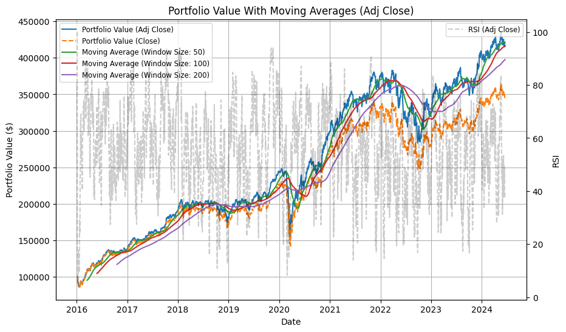

```python
#Criar o gráfico principal com o primeiro eixo y
fig, ax1 = plt.subplots(figsize=(10, 6))

# Plotar os valores do portfólio e médias móveis no primeiro eixo y
ax1.plot(portfolio_value_adj_close, label='Portfolio Value (Adj Close)')
ax1.plot(portfolio_value_close, linestyle='--', label='Portfolio Value (Close)')
ax1.plot(movie_average_adj_50, label='Moving Average (Window Size: 50)')
ax1.plot(movie_average_adj_100, label='Moving Average (Window Size: 100)')
ax1.plot(movie_average_adj_200, label='Moving Average (Window Size: 200)')

# Configurações do primeiro eixo y
ax1.set_xlabel('Date')
ax1.set_ylabel('Portfolio Value ($)')
ax1.grid(True)
ax1.legend(loc='upper left', fontsize='small')

# Criar o segundo eixo y para o RSI
ax2 = ax1.twinx()

# Plotar o RSI no segundo eixo y
ax2.plot(rsi_adj, linestyle='--', color='black', alpha=0.2, label='RSI (Adj Close)')

# Configurações do segundo eixo y
ax2.set_ylabel('RSI')
ax2.legend(loc='upper right', fontsize='small')

# Adicionar título
plt.title('Portfolio Value With Moving Averages (Adj Close)')

# Mostrar o gráfico
plt.show()
```

Para entender um pouco melhor a utilidade das médias móveis em finanças, vamos fazer uma explicação com a imagem abaixo:

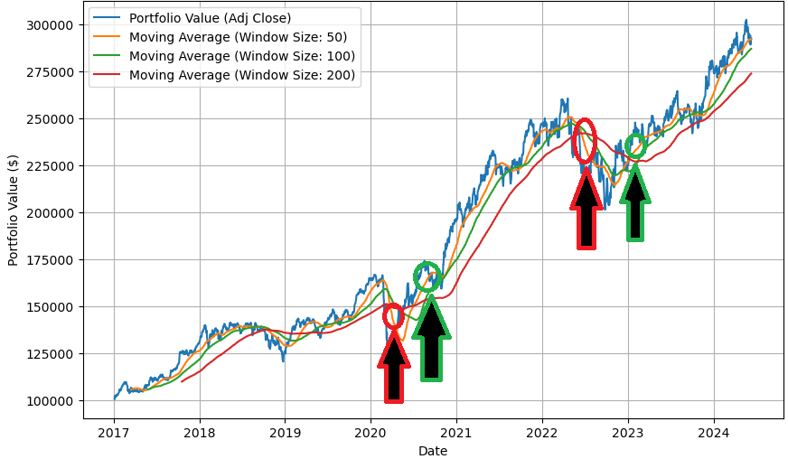

Quando uma média móvel com um período de 50 está abaixo de uma média móvel com período de 100 ou 200, isso indica que o ativo ou carteira está em um período de queda. Esse comportamento sugere que a média do retorno no curto prazo está menor que a média do retorno no longo prazo.

Na imagem acima, as setas e círculos vermelhos destacam os momentos em que a média móvel de 50 períodos está abaixo das médias móveis de 100 e 200 períodos. Quando isso ocorre, observamos uma queda nos retornos da carteira. Por outro lado, as setas e círculos verdes indicam situações em que a média móvel de 50 períodos está acima das médias móveis de 100 e 200 períodos. Esses eventos são geralmente acompanhados por uma tendência de alta nos retornos da carteira.

A análise de cruzamentos de médias móveis é uma ferramenta valiosa para identificar e confirmar tendências de mercado. Os cruzamentos negativos (quando a média de curto prazo cruza abaixo das médias de longo prazo) sinalizam uma possível continuação da tendência de queda, enquanto os cruzamentos positivos (quando a média de curto prazo cruza acima das médias de longo prazo) sugerem uma tendência de alta.